# Assignment 9 Report

Leah Ellis

2025-04-22

## Gradschool Admissions

The libraries used in this project are as follows:

```r
library(tidyverse)
library(modelr)
library(easystats)
library(GGally)
library(patchwork)
```

First, let’s read the data from the .csv file and give it a look.

```r
df <- read.csv("../../Data/GradSchool_Admissions.csv") %>% glimpse
```

```
## Rows: 400
## Columns: 4
## $ admit <int> 0, 1, 1, 1, 0, 1, 1, 0, 1, 0, 0, 0, 1, 0, 1, 0, 0, 0, 0, 1, 0, 1…
## $ gre   <int> 380, 660, 800, 640, 520, 760, 560, 400, 540, 700, 800, 440, 760,…
## $ gpa   <dbl> 3.61, 3.67, 4.00, 3.19, 2.93, 3.00, 2.98, 3.08, 3.39, 3.92, 4.00…
## $ rank  <int> 3, 3, 1, 4, 4, 2, 1, 2, 3, 2, 4, 1, 1, 2, 1, 3, 4, 3, 2, 1, 3, 2…
```

Hmm… there’s nothing blatantly bizarre with how this dataset is organized, but we could do a little bit of tidying at least.

```r
df_clean <- df %>%
  mutate(admit = ifelse(admit == 1, "True", "False")) %>%
  mutate(across(admit, as.factor)) %>%
  mutate(admit = factor(admit, levels=c("False", "True")))
```

Let’s use dplyr::mutate to change the 0 and 1 in the admit column to the much more “this-is-categorical-data” looking “True” and “False”. I also used the “mutate(across(…))” trick to change it into an ordered factor instead of a string. It feels more right to me that way, and it saves time later when labelling the graphs.

Speaking of graphs… let’s rename the columns too.

```r
df_clean <- df_clean %>%
  rename(Admit = admit) %>%
  rename(GRE = gre) %>%
  rename(GPA = gpa) %>%
  rename(Rank = rank)

df_clean %>% glimpse
```

```
## Rows: 400
## Columns: 4
## $ Admit <fct> False, True, True, True, False, True, True, False, True, False, …
## $ GRE   <int> 380, 660, 800, 640, 520, 760, 560, 400, 540, 700, 800, 440, 760,…
## $ GPA   <dbl> 3.61, 3.67, 4.00, 3.19, 2.93, 3.00, 2.98, 3.08, 3.39, 3.92, 4.00…
## $ Rank  <int> 3, 3, 1, 4, 4, 2, 1, 2, 3, 2, 4, 1, 1, 2, 1, 3, 4, 3, 2, 1, 3, 2…
```

That looks a lot more tidy to me.

## Exploration

Now let’s poke at what this dataset is actually trying to say.

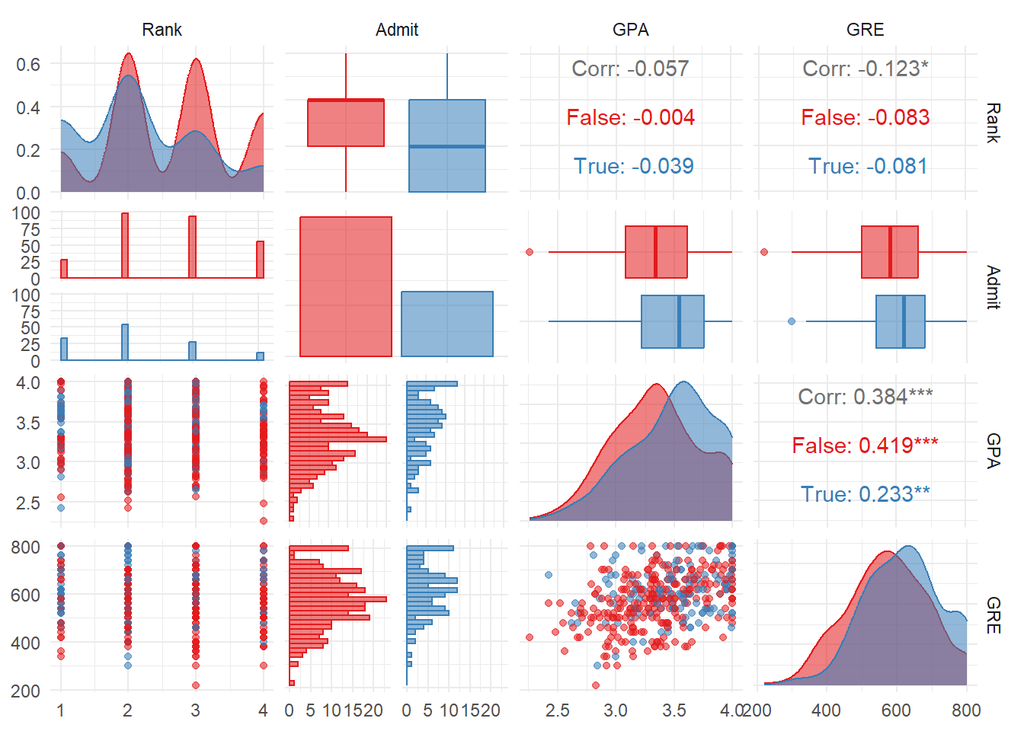

```r
df_clean %>% select(Rank, Admit, GPA, GRE) %>%
  GGally::ggpairs(aes(alpha=0.75, colour=Admit, fill = Admit)) + theme_minimal() + scale_color_brewer(palette="Set1") + scale_fill_brewer(palette="Set1")
```

GPA and GRE both have an effect on chance of admission, but it is smaller than one might expect. Let’s further seperate it by the rank of the admitting school.

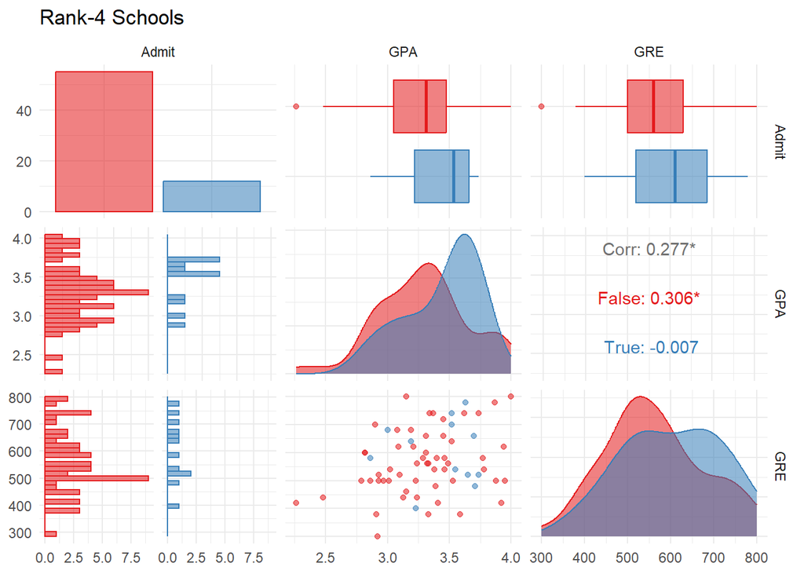

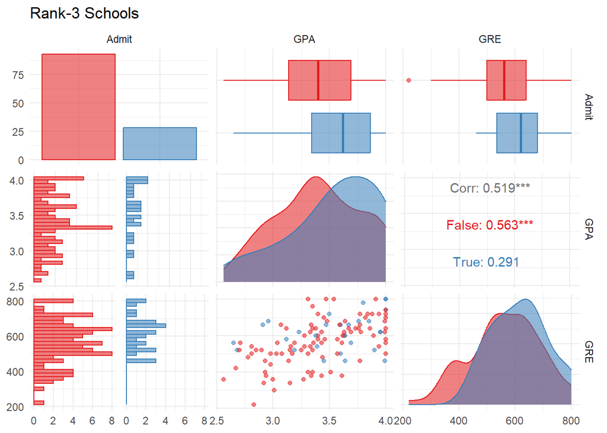

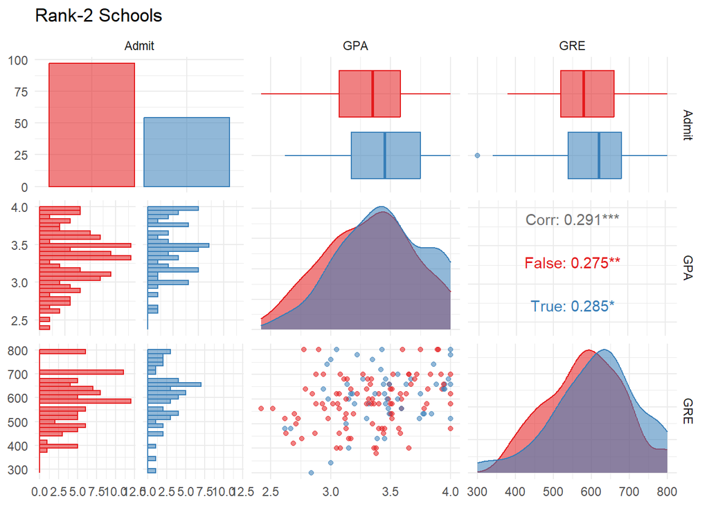

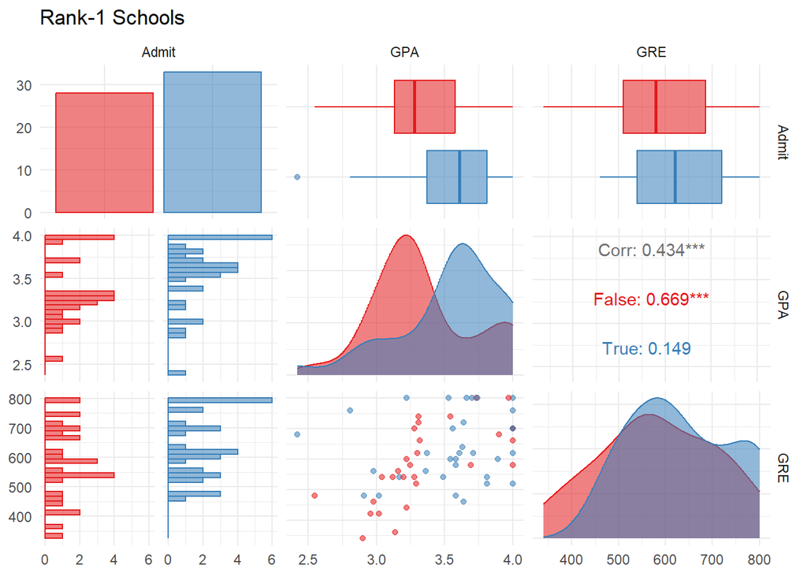

It looks like tougher schools (Rank 4?) are a bit rougher on GPA’s then lower rank schools- however, there are still a scattering of admissions across lower GPA’s even in the higher rank schools- which I find interesting.

Also of note, the assignment description says that the schools are ordered so that Rank 1 schools are “top-tier”:

```
the other columns are the GRE score, the GPA, and the rank of the undergraduate institution, where I is “top-tier.”
```

However, all of the data seems to point that being the contrary- with Rank 4 schools having the smallest proportion of accepted admissions.

# Modelling the Data

Now that we’ve taken a good look at the data, it’s time to make some models. I have chosen to try to make multiple generalized linear regression model to predict whether or not a student will be admitted to a school based off of the schools rank, and the student’s GPA and GRE. The family of the linear regresion model must be set to “binomial” given it is trying to predict a Boolean state (https://stats.stackexchange.com/questions/524510/logistic-regression-what-is-the-link-between-the-binomial-family-and-the-binomi).

```r
mod1 <- df_clean %>% glm(data=., family="binomial", Admit ~ GPA)
mod2 <- df_clean %>% glm(data=., family="binomial", Admit ~ GRE)
mod3 <- df_clean %>% glm(data=., family="binomial", Admit ~ Rank)
mod4 <- df_clean %>% glm(data=., family="binomial", Admit ~ Rank:GRE)
mod5 <- df_clean %>% glm(data=., family="binomial", Admit ~ Rank:GPA)
mod6 <- df_clean %>% glm(data=., family="binomial", Admit ~ Rank:GPA:GRE)
```

As per the example.knit from the gzhan github, I also tried using stepAIC on a very complicated model.

```r
mod7 <- df_clean %>% glm(data=., family="binomial", Admit ~ Rank * GPA * GRE)
mod8 <- df_clean %>% glm(data=., family="binomial", formula=MASS::stepAIC(mod7,trace=0))
```

Initially, let’s look at the mean square deviations alone.

```r
model_msds <- data.frame(
  names=c("mod1","mod2","mod3","mod4","mod5","mod6","mod7","mod8"),
  values=c(mean(mod1$residuals^2),mean(mod2$residuals^2),mean(mod3$residuals^2),mean(mod4$residuals^2),mean(mod5$residuals^2),mean(mod6$residuals^2),mean(mod7$residuals^2),mean(mod8$residuals^2)))

model_msds %>% arrange(model_msds$values)
```

```
##   names   values
## 1  mod6 4.705892
## 2  mod4 4.841748
## 3  mod2 4.873917
## 4  mod1 4.937191
## 5  mod5 5.013392
## 6  mod3 5.245100
## 7  mod7 5.921482
## 8  mod8 5.933248
```

It appears as if model 6 is the best model.

However, let’s try a more complicated analysis.

```r
compare_performance(mod1,mod2,mod3,mod4,mod5,mod6,mod7,mod8, rank=TRUE)
```

```
## # Comparison of Model Performance Indices
##
## Name | Model | Tjur's R2 |  RMSE | Sigma | Log_loss | Score_log
## ---------------------------------------------------------------
## mod8 |   glm |     0.105 | 0.440 | 1.000 |    0.571 |   -50.481
## mod3 |   glm |     0.060 | 0.451 | 1.000 |    0.595 |   -49.032
## mod7 |   glm |     0.106 | 0.440 | 1.000 |    0.570 |   -50.593
## mod5 |   glm |     0.037 | 0.456 | 1.000 |    0.607 |   -48.290
## mod1 |   glm |     0.032 | 0.458 | 1.000 |    0.609 |   -48.163
## mod2 |   glm |     0.034 | 0.458 | 1.000 |    0.608 |   -48.247
## mod4 |   glm |     0.021 | 0.461 | 1.000 |    0.615 |   -47.790
## mod6 |   glm |     0.009 | 0.463 | 1.000 |    0.620 |   -47.478
##
## Name | Score_spherical |   PCP | AIC weights | AICc weights | BIC weights | Performance-Score
## ---------------------------------------------------------------------------------------------
## mod8 |           0.004 | 0.612 |       0.943 |        0.948 |       0.634 |            68.20%
## mod3 |           0.010 | 0.593 |       0.001 |        0.001 |       0.359 |            45.93%
## mod7 |           0.005 | 0.613 |       0.056 |        0.050 |    9.44e-05 |            37.21%
## mod5 |           0.008 | 0.583 |    1.16e-05 |     1.24e-05 |       0.003 |            33.36%
## mod1 |           0.004 | 0.581 |    4.81e-06 |     5.15e-06 |       0.001 |            26.08%
## mod2 |           0.003 | 0.581 |    7.59e-06 |     8.12e-06 |       0.002 |            24.98%
## mod4 |           0.004 | 0.576 |    4.23e-07 |     4.52e-07 |    1.13e-04 |            24.58%
## mod6 |           0.004 | 0.571 |    4.64e-08 |     4.96e-08 |    1.24e-05 |            23.91%
```

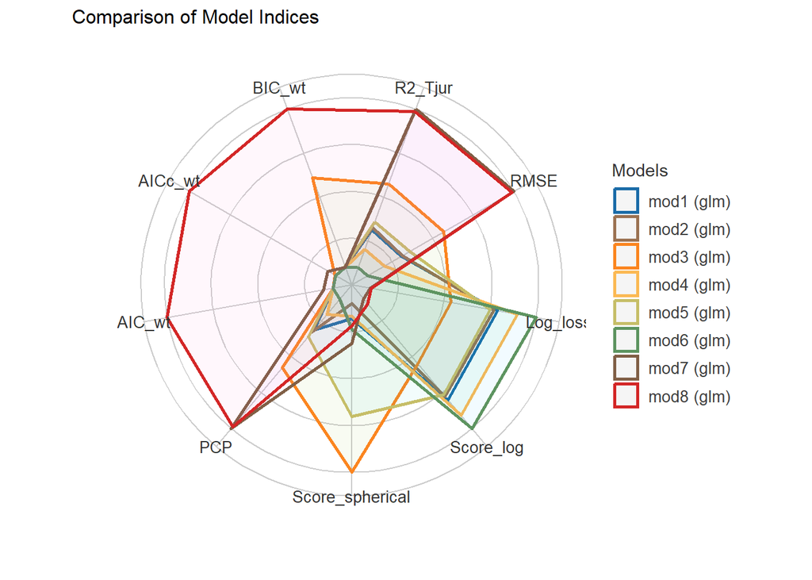

```r
compare_performance(mod1,mod2,mod3,mod4,mod5,mod6,mod7,mod8, rank=TRUE) %>% plot
```

Now- it looks like model 8 is the most performant.

# Oops!

Given how sort I am currently on time- I will end this assigment here. I feel that I was thorough for the section I did do at least. Thank’s for reading :)